# Caesar Cipher

Caesar cipher, also known as Caesar's cipher, the shift cipher, Caesar's code or Caesar shift, is one of the simplest and most widely known encryption techniques. It is a type of substitution cipher in which each letter in the plaintext is replaced by a letter some fixed number of positions down the alphabet. For example, with a left shift of 3, D would be replaced by A, E would become B, and so on.

## Algorithm

1. Input Plain Text, P from user.
2. Input Key, K from user.
3. During Encryption, each alphabet in the plaintext is Shifted to the right by K characters, in a cyclic order.
4. During Decryption, each alphabet in the plaintext is Shifted to the left by K characters, in a cyclic order.

**Example:**

Key = 2 and Plaintext = A

Encryption : **A -> B -> C** , therefore, Ciphertext = C

Decryption : **A <- B <- C** , therefore, Plaintext = A

## Encryption

The Alphabets A ... Z are represented as 0 ... 25 with A = 0 , B = 1 , ... , Z = 25

1. Each alphabet in P, is represented in its numeric form as mentioned above.
2. Modulus 26 is applied on the key, so that the key is within 0 to 26.
3. The output value is added to the numeric representation,
4. The resulting value if converted to its corresponding alphabet.

Mathematically,

**C<sub>n</sub> = P<sub>n</sub> + ( k mod 26 )** OR **C<sub>n</sub> = ( P<sub>n</sub> + k ) mod 26**

where,

**P<sub>n</sub>** is the *numeric representation* of the n<sup>th</sup> Charcter of the plaintext, P

**C<sub>n</sub>** is the *numeric representation* of the n<sup>th</sup> Charcter of the Ciphertext, C

**k** is the *key*

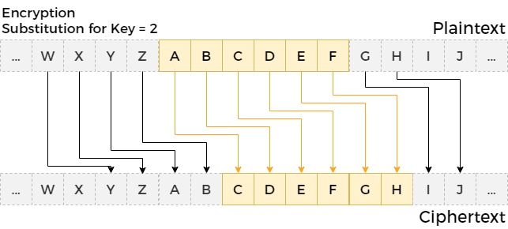

## Decryption

The Alphabets A ... Z are represented as 0 ... 25 with A = 0 , B = 1 , ... , Z = 25

1. Each alphabet in C, is represented in its numeric form as mentioned above.
2. Modulus 26 is applied on the key, so that the key is within 0 to 26.
3. The output value is subtracted from the the numeric representation,
4. The resulting value if converted to its corresponding alphabet.

Mathematically,

**P<sub>n</sub> = C<sub>n</sub> - ( k mod 26 )** OR **P<sub>n</sub> = ( C<sub>n</sub> - k ) mod 26**

where,

**P<sub>n</sub>** is the *numeric representation* of the n<sup>th</sup> Charcter of the plaintext, P

**C<sub>n</sub>** is the *numeric representation* of the n<sup>th</sup> Charcter of the Ciphertext, C

**k** is the *key*

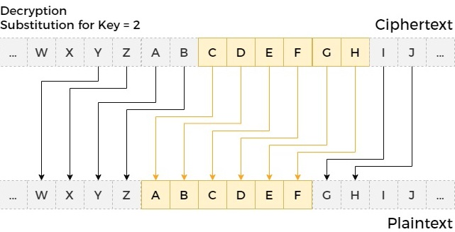

## Implementation of Caesar Cipher using Python

```python
def encrypt(plaintext, key):
    ciphertext = []
    for i in plaintext:
        if i.isupper() :
            ciphertext.append(chr((ord(i)+key-65)%26+65))
        elif i.islower():
            ciphertext.append(chr((ord(i)+key-97)%26+97))
        else:
            ciphertext.append(i)
    return "".join(ciphertext)

def decrypt(ciphertext, key):
    plaintext = []
    for i in ciphertext:
        if i.isupper() :
            plaintext.append(chr((ord(i)-key-65)%26+65))
        elif i.islower():
            plaintext.append(chr((ord(i)-key-97)%26+97))
        else:
            plaintext.append(i)
    return "".join(plaintext)

print("Welcome! This is Caesar Cipher's implementation in Python.")
print("----------------------------------------------------------")
print()
print("Caesar Cipher Encryption")
plaintext = input("  Enter Plaintext: ")
print("  Ciphertext: ",  encrypt(plaintext, int(input("  Enter the Key: "))))
print()
print("Caesar Cipher Decryption")
ciphertext = input("  Enter Ciphertext: ")
print("  Plaintext: ", decrypt(ciphertext, int(input("  Enter the Key: "))))
```

```
Welcome! This is Caesar Cipher's implementation in Python.
----------------------------------------------------------

Caesar Cipher Encryption
  Enter Plaintext: Caesar Cipher is not Secure
  Enter the Key: 56
  Ciphertext:  Geiwev Gmtliv mw rsx Wigyvi

Caesar Cipher Decryption
  Enter Ciphertext: Geiwev Gmtliv mw rsx Wigyvi
  Enter the Key: 56
  Plaintext:  Caesar Cipher is not Secure
```

#### Tanmoy Sen Gupta

tanmoysg.com | +91 9864809029 | tanmoysps@gmail.com